# Human Activity Recognition

Eric Rodriguez

February 28, 2016

# Background

Using devices such as Jawbone Up, Nike FuelBand, and Fitbit it is now possible to collect a large amount of data about personal activity relatively inexpensively. These type of devices are part of the quantified self movement – a group of enthusiasts who take measurements about themselves regularly to improve their health, to find patterns in their behavior, or because they are tech geeks. One thing that people regularly do is quantify how much of a particular activity they do, but they rarely quantify how well they do it. In this project, the goal is to use data from accelerometers on the belt, forearm, arm, and dumbell of 6 participants. They were asked to perform barbell lifts correctly and incorrectly in 5 different ways. More information is available from the website here: http://groupware.les.inf.puc-rio.br/har (see the section on the Weight Lifting Exercise Dataset). This project pretends to predict the manner in which they did the exercise using machine learning algorithms.

# Obtaining the data

```r
training_url <- "https://d396qusza40orc.cloudfront.net/predmachlearn/pml-training.csv"
testing_url <- "https://d396qusza40orc.cloudfront.net/predmachlearn/pml-testing.csv"
training <- read.csv(training_url, header = TRUE, na.strings = c("NA", ""))
testing <- read.csv(testing_url, header = TRUE, na.strings = c("NA", ""))

#remove predictors with more than 30% NAs
training <- training[, colSums(is.na(training)) < round(nrow(training)*0.3)]
```

```r
suppressWarnings(suppressMessages(library(caret)))
library(plot3D)
library(doParallel)
```

# Exploring the data

```r
table(training$classe)
```

```
##
##    A    B    C    D    E
## 5580 3797 3422 3216 3607
```

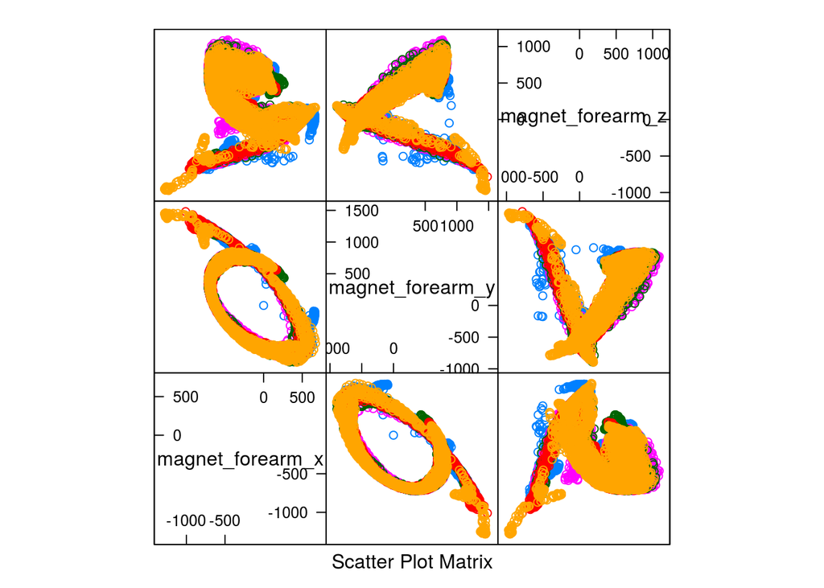

```r
featurePlot(x=training[,grep("^magnet_forearm", names(training))], y=training$classe, plot="pairs", title="Forearm motion")
```

```r
with(training, points3D(
  magnet_forearm_x,
  magnet_forearm_y,
  magnet_forearm_z,
  col=classe,
  main="Fore Arm",
  pch=20, cex=0.8
))
```

[figure not shown]

These graphs can be draw for all 4 main sensors: dumbbell, forearm, arm and belt.

# Splitting and preprocessing

```r
set.seed(2802)
inTrain <- createDataPartition(y=training$classe, p=0.70, list=FALSE)
trainSet <- training[inTrain,]
testSet <- training[-inTrain,]

# Center and scale all variables except 'classe'
preObj <- preProcess(subset(trainSet, select = -c(classe)), method="pca", thresh = 0.95)
# Let's look at the 12 most relevant ones
head(sort(abs(preObj$rotation[,1]), decreasing = TRUE), 12)
```

```
##         accel_belt_y         accel_belt_z     total_accel_belt
##            0.2940611            0.2788494            0.2661830
##            roll_belt          accel_arm_y     accel_dumbbell_y
##            0.2651575            0.2294477            0.2120685
##    magnet_dumbbell_x     accel_dumbbell_z raw_timestamp_part_1
##            0.2041558            0.1965681            0.1951511
## total_accel_dumbbell     accel_dumbbell_x         gyros_belt_z
##            0.1900310            0.1881108            0.1851457
```

# Model building

I’ll build a Gradient Boosting Machines (GBM)

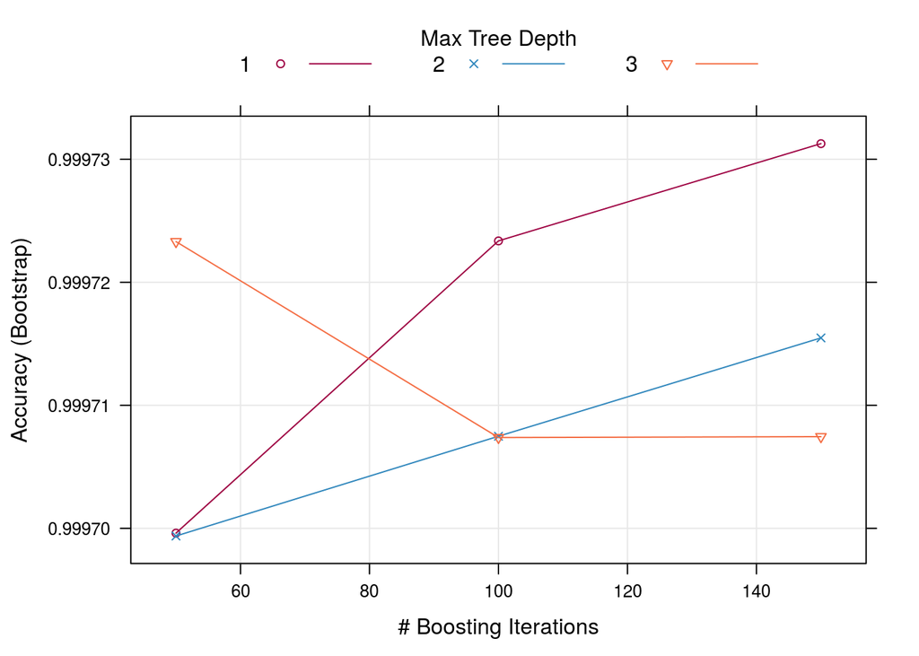

```r
set.seed(2802)
ctrl <- trainControl(preProcOptions = list(thresh = 0.95))
# Calculate the number of cores
ncores <- detectCores() - 1
# Initiate cluster
cl <- makeCluster(ncores)
registerDoParallel(cl)
modelGBM <- train(classe ~ ., method="gbm", data=trainSet, verbose=FALSE)
stopCluster(cl)

trellis.par.set(caretTheme())
plot(modelGBM)
```

```r
modelGBM
```

```
## Stochastic Gradient Boosting
##
## 13737 samples
##    59 predictors
##     5 classes: 'A', 'B', 'C', 'D', 'E'
##
## No pre-processing
## Resampling: Bootstrapped (25 reps)
## Summary of sample sizes: 13737, 13737, 13737, 13737, 13737, 13737, ...
## Resampling results across tuning parameters:
##
##   interaction.depth  n.trees  Accuracy   Kappa      Accuracy SD
##   1                   50      0.9996996  0.9996201  0.0002736598
##   1                  100      0.9997234  0.9996501  0.0002731173
##   1                  150      0.9997313  0.9996601  0.0002723980
##   2                   50      0.9996994  0.9996198  0.0002797352
##   2                  100      0.9997075  0.9996300  0.0003018738
##   2                  150      0.9997155  0.9996401  0.0003070324
##   3                   50      0.9997233  0.9996501  0.0002671151
##   3                  100      0.9997074  0.9996299  0.0002795902
##   3                  150      0.9997075  0.9996300  0.0002908237
##   Kappa SD
##   0.0003459849
##   0.0003454456
##   0.0003445376
##   0.0003537026
##   0.0003818548
##   0.0003883796
##   0.0003378595
##   0.0003536487
##   0.0003677373
##
## Tuning parameter 'shrinkage' was held constant at a value of 0.1
##
## Tuning parameter 'n.minobsinnode' was held constant at a value of 10
## Accuracy was used to select the optimal model using  the largest value.
## The final values used for the model were n.trees = 150,
##  interaction.depth = 1, shrinkage = 0.1 and n.minobsinnode = 10.
```

```r
set.seed(2802)
cl <- makeCluster(ncores)
registerDoParallel(cl)
modelRF <- train(classe ~ ., method="rf", data=trainSet, verbose=FALSE)
stopCluster(cl)

modelRF
```

```
## Random Forest
##
## 13737 samples
##    59 predictors
##     5 classes: 'A', 'B', 'C', 'D', 'E'
##
## No pre-processing
## Resampling: Bootstrapped (25 reps)
## Summary of sample sizes: 13737, 13737, 13737, 13737, 13737, 13737, ...
## Resampling results across tuning parameters:
##
##   mtry  Accuracy   Kappa      Accuracy SD   Kappa SD
##    2    0.9945954  0.9931620  0.0016089487  0.0020393922
##   41    0.9998500  0.9998103  0.0001730854  0.0002189704
##   81    0.9997709  0.9997103  0.0002466049  0.0003118154
##
## Accuracy was used to select the optimal model using  the largest value.
## The final value used for the model was mtry = 41.
```